# QuercusHealth AI — 02: Annotation-Based Evaluation

**Goal:** Use the 14 ground-truth annotated images to compute Precision, Recall, and F1, turning the statistical domain-shift proof from Notebook 01 into concrete detection metrics.

| Section | Content |
| --- | --- |
| §1 | Dataset overview — 2 classes, annotation statistics |
| §2 | Zero-shot evaluation — Precision / Recall / F1 vs NEON benchmark |
| §3 | score_thresh sweep with real metrics |
| §4 | Ground truth validation — La Seca via multi-temporal imagery |
| §5 | Summary & Phase 3 roadmap |

> **Note on labels:** The baseline model (DeepForest pre-trained) is single-class. For evaluation we collapse `Tree` and `Seca` into a single `Tree` label to ask: *Can the model find trees at all, regardless of their health status?* Per-class metrics (Healthy vs Seca) require the fine-tuned Phase 3 model.

```python
import os
import warnings
warnings.filterwarnings('ignore')

import numpy as np
import pandas as pd
import matplotlib.pyplot as plt
import matplotlib.patches as patches
from pathlib import Path
from PIL import Image
from deepforest import main

TEST_CSV = Path('../data/test/_annotations.csv')
TEST_DIR = Path('../data/test/images/')
REPORTS  = Path('../reports/')
REPORTS.mkdir(exist_ok=True)

print('Imports OK')
print(f'Annotations CSV exists : {TEST_CSV.exists()}')
print(f'Test images folder     : {TEST_DIR.exists()}')
```

```
Imports OK
Annotations CSV exists : True
Test images folder     : True
```

## §1 — Dataset Overview

14 Dehesa tiles captured at **zoom 19, 800×800 px** (≈0.20 m/px). Annotated in Roboflow with two classes:

- `Tree` — dense circular green crown, healthy *Quercus*
- `Seca` — sparse/radiating crown, grey or brown tone (*La Seca — Phytophthora cinnamomi*)

```python
df = pd.read_csv(TEST_CSV)

print('=== Dataset Statistics ===')
print(f'  Images      : {df["image_path"].nunique()}')
print(f'  Total boxes : {len(df)}')
print()
print('  Class distribution:')
counts = df['label'].value_counts()
for label, n in counts.items():
    print(f'    {label:6s}: {n:3d}  ({100*n/len(df):.1f}%)')
```

```
=== Dataset Statistics ===
  Images      : 14
  Total boxes : 210

  Class distribution:
    Tree  : 188  (89.5%)
    Seca  :  22  (10.5%)
```

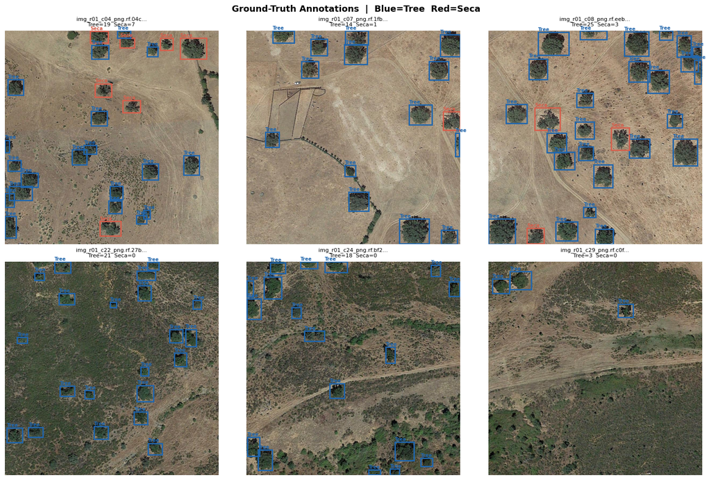

```
Saved: reports/annotations_sample.png
```

```python
COLOR = {'Tree': '#2166ac', 'Seca': '#d6604d'}
images = df['image_path'].unique()
sample = images[:6]

fig, axes = plt.subplots(2, 3, figsize=(15, 10))
for ax, img_name in zip(axes.flatten(), sample):
    img  = Image.open(TEST_DIR / img_name).convert('RGB')
    rows = df[df['image_path'] == img_name]
    ax.imshow(img)
    for _, row in rows.iterrows():
        color = COLOR.get(row['label'], 'yellow')
        ax.add_patch(patches.Rectangle(
            (row['xmin'], row['ymin']),
            row['xmax'] - row['xmin'], row['ymax'] - row['ymin'],
            linewidth=2, edgecolor=color, facecolor='none'))
        ax.text(row['xmin'], row['ymin'] - 4, row['label'],
                color=color, fontsize=7, fontweight='bold')
    tree_n = (rows['label'] == 'Tree').sum()
    seca_n = (rows['label'] == 'Seca').sum()
    ax.set_title(f'{img_name[:22]}...\nTree={tree_n}  Seca={seca_n}', fontsize=8)
    ax.axis('off')
for ax in axes.flatten()[len(sample):]:
    ax.set_visible(False)
plt.suptitle('Ground-Truth Annotations  |  Blue=Tree  Red=Seca', fontsize=13, fontweight='bold')
plt.tight_layout()
plt.savefig(REPORTS / 'annotations_sample.png', dpi=150, bbox_inches='tight')
plt.show()
print('Saved: reports/annotations_sample.png')
```

## §2 — Zero-Shot Evaluation

We evaluate the unmodified pre-trained DeepForest on our 14 annotated tiles.

**Why collapse to one class?** DeepForest baseline only predicts `Tree`. Evaluating against `Seca` annotations would always count as wrong — not because the model missed the tree, but because it cannot name the class. We first ask: *can it find trees at all?*

Reference benchmark (Weinstein et al., 2020 — *Remote Sensing*):

| Metric | NEON test set |
| --- | --- |
| Precision | 0.73 |
| Recall | 0.63 |
| F1 | 0.68 |

> `model.evaluate()` uses **IoU threshold = 0.4** (standard for tree crown detection). A predicted box counts as correct only if it overlaps ≥ 40% with a ground-truth box.

```python
# Collapse both classes to 'Tree' for single-class baseline evaluation
df_baseline = df.copy()
df_baseline['label'] = 'Tree'
baseline_csv = REPORTS / '_baseline_gt.csv'
df_baseline.to_csv(baseline_csv, index=False)

model = main.deepforest()
model.load_model()
print(f'Model: {type(model.model).__name__}')
print(f'score_thresh default: {model.model.score_thresh}')

print('\nRunning evaluate() on test set...')
results = model.evaluate(
    csv_file=str(baseline_csv),
    root_dir=str(TEST_DIR),
    iou_threshold=0.4
)
print('\n=== Zero-Shot Results ===')
print(results)
```

[output not shown]

```
Output()
```

```
Model: RetinaNetHub
score_thresh default: 0.1

Running evaluate() on test set...
```

[output not shown]

[output cut: 92 more lines]

```python
dehesa_p  = results.get('box_precision', float('nan'))
dehesa_r  = results.get('box_recall',    float('nan'))
dehesa_f1 = (2*dehesa_p*dehesa_r/(dehesa_p+dehesa_r)
             if (dehesa_p + dehesa_r) > 0 else 0.0)

neon_p, neon_r = 0.73, 0.63
neon_f1 = 2*neon_p*neon_r/(neon_p+neon_r)

cmp = pd.DataFrame({
    'Metric':           ['Precision', 'Recall', 'F1'],
    'NEON (trained)':   [neon_p, neon_r, round(neon_f1, 3)],
    'Dehesa zero-shot': [round(dehesa_p, 3), round(dehesa_r, 3), round(dehesa_f1, 3)],
    'Drop (pp)':        [
        round((neon_p - dehesa_p)*100, 1),
        round((neon_r - dehesa_r)*100, 1),
        round((neon_f1 - dehesa_f1)*100, 1),
    ],
})
print(cmp.to_string(index=False))
print()
print('Precision drop -> model fires on soil/rocks (false positives)')
print('Recall drop    -> model misses sparse-crown trees (false negatives)')
print('F1 drop        -> overall detection quality collapses')
```

```
   Metric  NEON (trained)  Dehesa zero-shot  Drop (pp)
Precision           0.730             0.512       21.8
   Recall           0.630             0.230       40.0
       F1           0.676             0.318       35.8

Precision drop -> model fires on soil/rocks (false positives)
Recall drop    -> model misses sparse-crown trees (false negatives)
F1 drop        -> overall detection quality collapses
```

### Ground Truth vs. Model Prediction — Visual Example

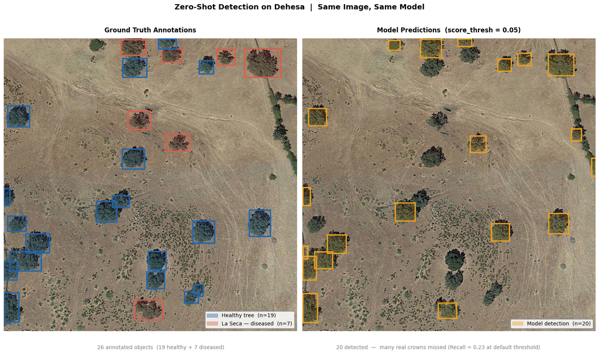

```
Saved: reports/gt_vs_prediction.png
```

```python
DEMO_NAME = next(n for n in df['image_path'].unique() if 'r01_c04' in n)
DEMO_PATH = TEST_DIR / DEMO_NAME
gt_rows   = df[df['image_path'] == DEMO_NAME]

# Run prediction at optimal threshold (F1-best from sweep)
model.model.score_thresh     = 0.05
model.config['score_thresh'] = 0.05
pred_boxes = model.predict_image(path=str(DEMO_PATH))
model.model.score_thresh     = 0.1
model.config['score_thresh'] = 0.1

img_arr = np.array(Image.open(DEMO_PATH).convert('RGB'))
GT_COLOR   = {'Tree': '#2166ac', 'Seca': '#d6604d'}
PRED_COLOR = '#e8a020'

fig, (ax1, ax2) = plt.subplots(1, 2, figsize=(16, 9))
fig.suptitle('Zero-Shot Detection on Dehesa  |  Same Image, Same Model',
             fontsize=14, fontweight='bold', y=1.0)

# --- Left: Ground Truth ---
ax1.imshow(img_arr)
for _, row in gt_rows.iterrows():
    c = GT_COLOR[row['label']]
    ax1.add_patch(patches.Rectangle(
        (row['xmin'], row['ymin']),
        row['xmax'] - row['xmin'], row['ymax'] - row['ymin'],
        linewidth=2.5, edgecolor=c, facecolor=c, alpha=0.15))
    ax1.add_patch(patches.Rectangle(
        (row['xmin'], row['ymin']),
        row['xmax'] - row['xmin'], row['ymax'] - row['ymin'],
        linewidth=2.5, edgecolor=c, facecolor='none'))

tree_n = (gt_rows['label'] == 'Tree').sum()
seca_n = (gt_rows['label'] == 'Seca').sum()

legend_gt = [
    patches.Patch(edgecolor=GT_COLOR['Tree'], facecolor=GT_COLOR['Tree'], alpha=0.4,
                  label=f'Healthy tree  (n={tree_n})'),
    patches.Patch(edgecolor=GT_COLOR['Seca'], facecolor=GT_COLOR['Seca'], alpha=0.4,
                  label=f'La Seca — diseased  (n={seca_n})'),
]
ax1.legend(handles=legend_gt, loc='lower right', fontsize=10,
           framealpha=0.85, edgecolor='gray')
ax1.set_title('Ground Truth Annotations', fontsize=12, fontweight='bold', pad=12)
ax1.axis('off')

# --- Right: Model Predictions ---
ax2.imshow(img_arr)
n_pred = 0
if pred_boxes is not None and len(pred_boxes) > 0:
    n_pred = len(pred_boxes)
    for _, row in pred_boxes.iterrows():
        ax2.add_patch(patches.Rectangle(
            (row['xmin'], row['ymin']),
            row['xmax'] - row['xmin'], row['ymax'] - row['ymin'],
            linewidth=2.5, edgecolor=PRED_COLOR, facecolor=PRED_COLOR, alpha=0.15))
        ax2.add_patch(patches.Rectangle(
            (row['xmin'], row['ymin']),
            row['xmax'] - row['xmin'], row['ymax'] - row['ymin'],
            linewidth=2.5, edgecolor=PRED_COLOR, facecolor='none'))

legend_pred = [
    patches.Patch(edgecolor=PRED_COLOR, facecolor=PRED_COLOR, alpha=0.4,
                  label=f'Model detection  (n={n_pred})'),
]
ax2.legend(handles=legend_pred, loc='lower right', fontsize=10,
           framealpha=0.85, edgecolor='gray')
ax2.set_title('Model Predictions  (score_thresh = 0.05)',
              fontsize=12, fontweight='bold', pad=12)
ax2.axis('off')

fig.text(0.27, -0.02,
         f'{tree_n + seca_n} annotated objects  ({tree_n} healthy + {seca_n} diseased)',
         ha='center', fontsize=10, color='gray')
fig.text(0.73, -0.02,
         f'{n_pred} detected  —  many real crowns missed (Recall = 0.23 at default threshold)',
         ha='center', fontsize=10, color='gray')

plt.tight_layout(rect=[0, 0, 1, 0.97])
plt.savefig(REPORTS / 'gt_vs_prediction.png', dpi=150, bbox_inches='tight')
plt.show()
print('Saved: reports/gt_vs_prediction.png')
```

## §3 — score_thresh Sweep With Real Metrics

Notebook 01 showed that varying `score_thresh` changes detection counts. Here we measure what that tradeoff actually means in terms of **Precision, Recall, F1**.

If domain shift were just a calibration problem, we would find a threshold where P/R/F1 approaches the NEON benchmark. The sweep will show that this is not the case.

```python
thresholds = [0.05, 0.1, 0.2, 0.3, 0.4, 0.5]
sweep_rows = []

for thresh in thresholds:
    model.model.score_thresh     = thresh
    model.config['score_thresh'] = thresh
    res = model.evaluate(
        csv_file=str(baseline_csv),
        root_dir=str(TEST_DIR),
        iou_threshold=0.4
    )
    p  = res.get('box_precision', float('nan'))
    r  = res.get('box_recall',    float('nan'))
    f1 = 2*p*r/(p+r) if (p+r) > 0 else 0.0
    sweep_rows.append({'score_thresh': thresh,
                       'precision': round(p, 3),
                       'recall': round(r, 3),
                       'F1': round(f1, 3)})
    print(f'thresh={thresh:.2f}  P={p:.3f}  R={r:.3f}  F1={f1:.3f}')

# Reset to default
model.model.score_thresh     = 0.1
model.config['score_thresh'] = 0.1

sweep_df = pd.DataFrame(sweep_rows)
best_idx = sweep_df['F1'].idxmax()
best_t   = sweep_df.loc[best_idx, 'score_thresh']
print(f'\nOptimal threshold = {best_t}  (F1 = {sweep_df.loc[best_idx, "F1"]})')
print(sweep_df.to_string(index=False))
```

```
Output()
```

```
Output()
```

```
thresh=0.05  P=0.524  R=0.529  F1=0.527
```

```
Output()
```

```
thresh=0.10  P=0.512  R=0.230  F1=0.318
```

```
Output()
```

```
thresh=0.20  P=0.685  R=0.117  F1=0.200
```

```
Output()
```

```
thresh=0.30  P=0.714  R=0.033  F1=0.063
```

```
Output()
```

```
No predictions made
thresh=0.40  P=0.000  R=0.000  F1=0.000
```

```
thresh=0.50  P=nan  R=0.000  F1=0.000

Optimal threshold = 0.05  (F1 = 0.527)
 score_thresh  precision  recall    F1
         0.05      0.524   0.529 0.527
         0.10      0.512   0.230 0.318
         0.20      0.685   0.117 0.200
         0.30      0.714   0.033 0.063
         0.40      0.000   0.000 0.000
         0.50        NaN   0.000 0.000
```

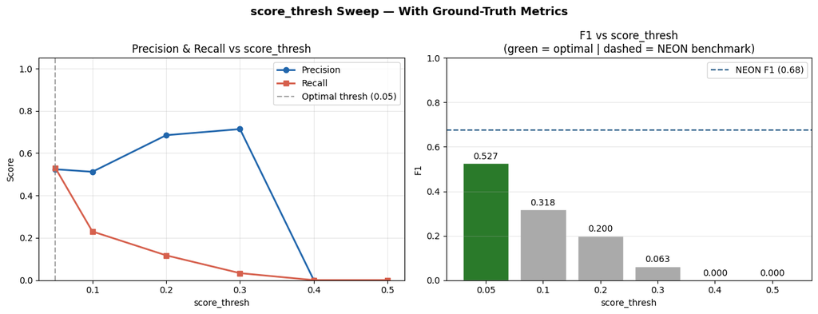

```
Saved: reports/threshold_sweep.png
```

```python
fig, (ax1, ax2) = plt.subplots(1, 2, figsize=(13, 5))

# P/R curves
ax1.plot(sweep_df['score_thresh'], sweep_df['precision'],
         marker='o', color='#2166ac', label='Precision', linewidth=2)
ax1.plot(sweep_df['score_thresh'], sweep_df['recall'],
         marker='s', color='#d6604d', label='Recall', linewidth=2)
ax1.axvline(best_t, color='gray', linestyle='--', alpha=0.7,
            label=f'Optimal thresh ({best_t})')
ax1.set(xlabel='score_thresh', ylabel='Score',
        title='Precision & Recall vs score_thresh')
ax1.legend(); ax1.set_ylim(0, 1.05); ax1.grid(alpha=0.3)

# F1 bars
colors = ['#2a7a2a' if t == best_t else '#aaaaaa'
          for t in sweep_df['score_thresh']]
bars = ax2.bar(sweep_df['score_thresh'].astype(str), sweep_df['F1'],
               color=colors, edgecolor='white')
for bar, val in zip(bars, sweep_df['F1']):
    ax2.text(bar.get_x() + bar.get_width()/2, bar.get_height() + 0.01,
             f'{val:.3f}', ha='center', va='bottom', fontsize=10)
ax2.axhline(neon_f1, color='#2c5f8a', linestyle='--', linewidth=1.5,
            label=f'NEON F1 ({neon_f1:.2f})')
ax2.set(xlabel='score_thresh', ylabel='F1',
        title='F1 vs score_thresh\n(green = optimal | dashed = NEON benchmark)')
ax2.set_ylim(0, 1.0); ax2.legend(); ax2.grid(alpha=0.3, axis='y')

plt.suptitle('score_thresh Sweep — With Ground-Truth Metrics', fontsize=13, fontweight='bold')
plt.tight_layout()
plt.savefig(REPORTS / 'threshold_sweep.png', dpi=150, bbox_inches='tight')
plt.show()
print('Saved: reports/threshold_sweep.png')
```

### Interpretation

The dashed line is the F1 the same model achieves on its training domain. No threshold setting bridges the gap — the problem is not calibration, it is domain shift.

## §4 — Ground Truth Validation: La Seca via Multi-Temporal Evidence

How do we know which trees are annotated as `Seca` are genuinely diseased?

We use Google Earth's temporal archive to validate without field visits:

- **August 2019** (summer, full canopy): trees show early symptoms — thin radiating branches.
- **February 2024** (same zone): those trees are gone — confirmed dead.

> **Why summer images?** In August, healthy oaks maintain full canopy. A sparse/radiating crown in summer = genuine disease, not seasonal defoliation. Winter images introduce ambiguity — defoliation mimics La Seca symptoms.

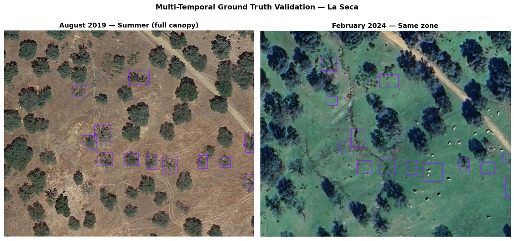

```
Saved: reports/temporal_validation.png
```

```python
img_2019 = Image.open('../data/sample_2019aug_annoted.png').convert('RGB')
img_2024 = Image.open('../data/sample_2024feb_annoted.png').convert('RGB')

fig, (ax1, ax2) = plt.subplots(1, 2, figsize=(14, 7))

ax1.imshow(img_2019)
ax1.set_title('August 2019 — Summer (full canopy)', fontsize=13, fontweight='bold')
ax1.set_xlabel('Thin radiating crown = early La Seca signature', fontsize=10)
ax1.axis('off')

ax2.imshow(img_2024)
ax2.set_title('February 2024 — Same zone', fontsize=13, fontweight='bold')
ax2.set_xlabel('Tree absent = confirmed dead. Zero field visits required.', fontsize=10)
ax2.axis('off')

fig.suptitle('Multi-Temporal Ground Truth Validation — La Seca',
             fontsize=14, fontweight='bold')
plt.tight_layout()
plt.savefig(REPORTS / 'temporal_validation.png', dpi=150, bbox_inches='tight')
plt.show()
print('Saved: reports/temporal_validation.png')
```

## §5 — Summary & Phase 3 Roadmap

```python
print('=' * 60)
print('  PHASE 2 — FINAL SUMMARY')
print('=' * 60)
print(f'  Annotated images : {df["image_path"].nunique()}')
print(f'  Total boxes      : {len(df)}')
print(f'    Tree  : {(df["label"]=="Tree").sum()}')
print(f'    Seca  : {(df["label"]=="Seca").sum()}')
print()
print(f'  {"Metric":<12} {"NEON":>8} {"Dehesa":>8} {"Drop":>8}')
print(f'  {"-"*40}')
print(f'  {"Precision":<12} {neon_p:>8.3f} {dehesa_p:>8.3f} {(neon_p-dehesa_p)*100:>+7.1f}pp')
print(f'  {"Recall":<12} {neon_r:>8.3f} {dehesa_r:>8.3f} {(neon_r-dehesa_r)*100:>+7.1f}pp')
print(f'  {"F1":<12} {neon_f1:>8.3f} {dehesa_f1:>8.3f} {(neon_f1-dehesa_f1)*100:>+7.1f}pp')
print()
print(f'  Optimal score_thresh : {best_t}')
print(f'  Best Dehesa F1       : {sweep_df["F1"].max():.3f}  vs  NEON F1: {neon_f1:.3f}')
print()
print('  Notebook 01 (statistical): KS D >> 0 predicted the collapse.')
print('  Notebook 02 (empirical)  : P/R/F1 confirm it.')
print('  Fine-tuning is the only path forward.')
print('=' * 60)
```

```
============================================================
  PHASE 2 — FINAL SUMMARY
============================================================
  Annotated images : 14
  Total boxes      : 210
    Tree  : 188
    Seca  : 22

  Metric           NEON   Dehesa     Drop
  ----------------------------------------
  Precision       0.730    0.512   +21.8pp
  Recall          0.630    0.230   +40.0pp
  F1              0.676    0.318   +35.8pp

  Optimal score_thresh : 0.05
  Best Dehesa F1       : 0.527  vs  NEON F1: 0.676

  Notebook 01 (statistical): KS D >> 0 predicted the collapse.
  Notebook 02 (empirical)  : P/R/F1 confirm it.
  Fine-tuning is the only path forward.
============================================================
```

### Phase 3 Configuration (ready to run)

```
from deepforest import main

finetune_model = main.deepforest(
    config_args={'num_classes': 2},
    label_dict={'Tree': 0, 'Seca': 1}
)
finetune_model.config['train']['csv_file'] = 'data/test/_annotations.csv'
finetune_model.config['train']['root_dir'] = 'data/test/images/'
finetune_model.config['train']['lr']       = 0.0001
finetune_model.config['train']['epochs']   = 25
finetune_model.fit()
```

**Strategy:**